# Introduction to Data Science Activity A3b: Bivariate Visualization

Joe Margolis

The outcome of the 2016 presidential election surprised many people. In this activity we will analyze data from the 2016 presidential election. To better understand it ourselves, we’ll explore county-level election outcomes and demographics. The data set, prepared by Alicia Johnson, combines 2008/2012/2016 county-level election returns from [Tony McGovern on github](https://github.com/tonmcg/County_Level_Election_Results_12-16), county-level demographics from the `df_county_demographics` data set within the `choroplethr` R package, and red/purple/blue state designations from http://www.270towin.com/.

# 1 Getting to know the dataset

**Exercise 1.1** Begin by loading the data from “https://www.macalester.edu/~ajohns24/data/electionDemographics16.csv” and getting to know the data. Follow the prompts below to guide you.

```r
# Load data from "https://www.macalester.edu/~ajohns24/data/electionDemographics16.csv"
elect <- read_csv("https://www.macalester.edu/~ajohns24/data/electionDemographics16.csv")
# Check out the first rows of elect.  What are the units of observation?
head(elect)
# How much data do we have?
dim(elect)
# What are the names of the variables?
colnames(elect)
```

**Solution**

```r
# Load data from "https://www.macalester.edu/~ajohns24/data/electionDemographics16.csv"
elect <- read_csv("https://www.macalester.edu/~ajohns24/data/electionDemographics16.csv")

# Check out the first rows of elect.  What are the units of observation?  The variables?
head(elect)
## # A tibble: 6 × 34
##   county      total_2008 dem_2008 gop_2008 oth_2008 total_2012 dem_2012 gop_2012
##   <chr>            <dbl>    <dbl>    <dbl>    <dbl>      <dbl>    <dbl>    <dbl>
## 1 Walker Cou…      28652     7420    20722      510      28497     6551    21633
## 2 Bullock Co…       5415     4011     1391       13       5318     4058     1250
## 3 Calhoun Co…      49242    16334    32348      560      46240    15500    30272
## 4 Barbour Co…      11630     5697     5866       67      11459     5873     5539
## 5 Fayette Co…       7957     1994     5883       80       7912     1803     6034
## 6 Baldwin Co…      81413    19386    61271      756      84988    18329    65772
## # … with 26 more variables: oth_2012 <dbl>, total_2016 <dbl>, dem_2016 <dbl>,
## #   gop_2016 <dbl>, oth_2016 <dbl>, perdem_2016 <dbl>, perrep_2016 <dbl>,
## #   winrep_2016 <lgl>, perdem_2012 <dbl>, perrep_2012 <dbl>, winrep_2012 <lgl>,
## #   perdem_2008 <dbl>, perrep_2008 <dbl>, winrep_2008 <lgl>, region <dbl>,
## #   total_population <dbl>, percent_white <dbl>, percent_black <dbl>,
## #   percent_asian <dbl>, percent_hispanic <dbl>, per_capita_income <dbl>,
## #   median_rent <dbl>, median_age <dbl>, polyname <chr>, abb <chr>, …

# How much data do we have?
dim(elect)
## [1] 3112   34

# What are the names of the variables?
colnames(elect)
##  [1] "county"            "total_2008"        "dem_2008"
##  [4] "gop_2008"          "oth_2008"          "total_2012"
##  [7] "dem_2012"          "gop_2012"          "oth_2012"
## [10] "total_2016"        "dem_2016"          "gop_2016"
## [13] "oth_2016"          "perdem_2016"       "perrep_2016"
## [16] "winrep_2016"       "perdem_2012"       "perrep_2012"
## [19] "winrep_2012"       "perdem_2008"       "perrep_2008"
## [22] "winrep_2008"       "region"            "total_population"
## [25] "percent_white"     "percent_black"     "percent_asian"
## [28] "percent_hispanic"  "per_capita_income" "median_rent"
## [31] "median_age"        "polyname"          "abb"
## [34] "StateColor"
```

**Exercise 1.2** Explore the win column: The `winrep_2016` variable indicates whether or not the Republican (Trump) won the county in 2016, thus is *categorical*. Let’s construct both numerical and visual summaries of Trump wins/losses. (Before you do, what do you anticipate?)

```r
#Construct a table (a numerical summary) of the number of counties that Trump won/lost
table(elect$winrep_2016)

#Attach a library needed for ggplots
library(ggplot2)

#Construct a bar chart (a visual summary) of this variable.
ggplot(elect, aes(x = winrep_2016))
ggplot(elect, aes(x = winrep_2016)) +
    geom_bar()
```

**Solution**

```r
#Construct a table (a numerical summary) of the number of counties that Trump won/lost
table(elect$winrep_2016)

#Attach a library needed for ggplots
library(ggplot2)

#Construct a bar chart (a visual summary) of this variable.
ggplot(elect, aes(x=winrep_2016)) +
    geom_bar()
```

**Exercise 1.3 (Explore Vote Percentages)** The `perrep_2016` variable includes a bit more detail about Trump’s support in each county.

1. Since it’s *quantitative* we need different tools to visually explore the variability in `perrep_2016`. To this end, construct & interpret both a histogram and density plot of `perrep_2016`. (Before you do, what do you anticipate?)

   ```r
   ggplot(elect, aes(x = county, y = perrep_2016))

   #histogram
   ggplot(elect, aes(x = perrep_2016)) +
       geom_histogram(color="white")

   #density plot
   ggplot(elect, aes(x = perrep_2016)) +
       geom_density()
   ```

2. Thus far, we have a good sense for how Trump’s support varied from county to county. We don’t yet have a good sense for *why*. What other variables (ie. county features) might explain some of the variability in Trump’s support from county to county? Which of these variables do you think will be the best predictors of support? The worst?

B.) The difference is likely difference between rural counties and urban counties as the counties towards the left of the graoh with a low percentage of trump votes are likely more urban than the ones towards the right

**Solution**

```r
ggplot(elect, aes(x=perrep_2016))

#histogram
ggplot(elect, aes(x=perrep_2016)) +
    geom_histogram(color="white")

#density plot
ggplot(elect, aes(x=perrep_2016)) +
    geom_density()
```

# 2 Background on visualizing relationships

We’ve come up with a list of variables that might explain some of the variability in Trump’s support from county to county. Thus we’re interested in the relationship between:

- **response variable**: the variable whose variability we would like to explain (Trump’s percent of the vote)
- **predictors**: variables that might explain some of the variability in the response (percent white, per capita income, state color, etc)

Our goal is to construct visualizations that allow us to examine/identify the following features of the relationships among these variables:

- relationship *trends*
- relationship *strength* (degree of variability from the trend)
- *outliers* in the relationship

Before constructing visualizations of the relationship among any set of these variables, we need to understand what features these should have. As with univariate plots, the appropriate visualization also depends upon whether the variables are quantitative or categorical. Recall some **basic rules in constructing graphics:**

- Each **quantitative variable** requires a new axis. (We’ll discuss later what to do when we run out of axes!)
- Each **categorical variable** requires a new way to “group” the graphic (eg: using colors, shapes, separate facets, etc to capture the grouping)
- For visualizations in which **overlap** in glyphs or plots obscures the patterns, try faceting or transparency.

**Exercise 2.1 (Mock-Ups)** Consider a subset of the variables:

| county | abb | perrep_2016 | perrep_2012 | winrep_2016 | StateColor |
| --- | --- | --- | --- | --- | --- |
| Elbert County | CO | 73.53 | 72.52 | TRUE | blue |
| Rockdale County | GA | 35.82 | 41.37 | FALSE | purple |
| Clay County | MN | 46.55 | 44.91 | TRUE | blue |
| McDonald County | MO | 80.15 | 72.84 | TRUE | purple |
| Alcorn County | MS | 79.95 | 75.11 | TRUE | red |
| Roger Mills County | OK | 87.94 | 83.75 | TRUE | red |

In groups, sketch on paper a mock-up of a visualization of the relationship between the given pair of variables (i.e., what type of chart is appropriate to demonstrate the relationship?):

1. The relationship between `perrep_2016` (the response) and `perrep_2012` (the predictor).
2. The relationship between `perrep_2016` (the response) and `StateColor` (the predictor). Think: how might we modify the below density plot of `perrep_2016` to distinguish between counties in red/purple/blue states?

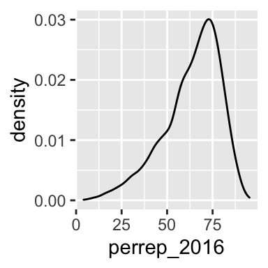

   ```r
   ggplot(elect, aes(x=perrep_2016)) +
       geom_density()
   ```

3. The relationship between Trump’s county-levels wins/losses `winrep_2016` (the response) and `StateColor` (the predictor). Think: how might we modify the below bar plot of `winrep_2016` to distinguish between counties in red/purple/blue states?

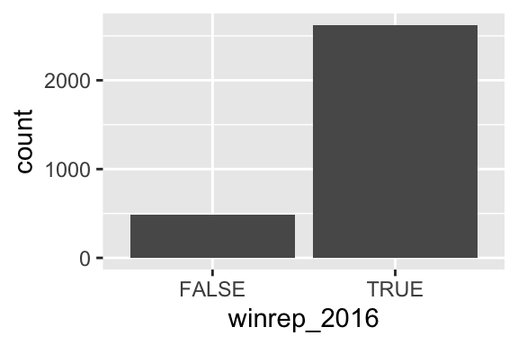

   ```r
   ggplot(elect, aes(x=winrep_2016)) +
       geom_bar()
   ```

# 3 Visualizing quantitiative vs quantitative relationships

Let’s start by exploring the relationship between Trump’s 2016 support (`perrep_2016`) and Romney’s 2012 support (`perrep_2012`), both quantitative variables.

**Exercise 3.1 (Scatterplots and Glyphs)** Both `perrep_2016` and `perrep_2012` are quantitative, thus require their own axes. Traditionally, the response variable is placed on the y-axis. Once the axes are set up, each case is represented by a “glyph” at the coordinates defined by these axes.

1. Make a scatterplot of `perrep_2016` vs `perrep_2012` with different glyphs: points or text.

   ```r
   #just a graphics frame
   ggplot(elect, aes(y=perrep_2016, x=perrep_2012))

   #add a layer with "point" glyphs
   ggplot(elect, aes(y=perrep_2016, x=perrep_2012)) +
       geom_point()

   #add a layer with symbol glyphs
   ggplot(elect, aes(y=perrep_2016, x=perrep_2012)) +
       geom_point(shape=3)

   #add a layer with "text" glyphs
   ggplot(elect, aes(y=perrep_2016, x=perrep_2012)) +
       geom_text(aes(label=abb))
   ```

2. Summarize the relationship between the Republican candidates’ support in 2016 and 2012. Be sure to comment on:  
   - the strength of the relationship (weak/moderate/strong)  
   - the direction of the relationship (positive/negative)  
   - outliers (In what state do counties deviate from the national trend? Explain why this might be the case)

   ```
    There is a strong, positive correlation between the percentage of representation from a county in 2016 and 2012. That is telling that not many places changed the way they voted in 2016. The places that had a higher percentage of republican votes in 2012 tended to be the same places that had higher percentage of republican votes in 2016. We do though see outliers in Idaho and Utah below the graph which tells us that some counties in Idaho and Utah changed and had a lower percentage of republican votes in 2016 than 2012.
   ```

**Exercise 3.2 (Capture the Trend with ‘smooths’)** The trend of the relationship between `perrep_2016` and `perrep_2012` is clearly positive and (mostly) linear. We can highlight this trend by adding a model “smooth” to the plot.

1. Add a layer with a model smooth:

   ```r
   ggplot(elect, aes(y=perrep_2016, x=perrep_2012)) +
       geom_point() +
       geom_smooth()
   ```

2. Construct a new plot that contains the model smooth but does not include the individual cases (eg: point glyphs).

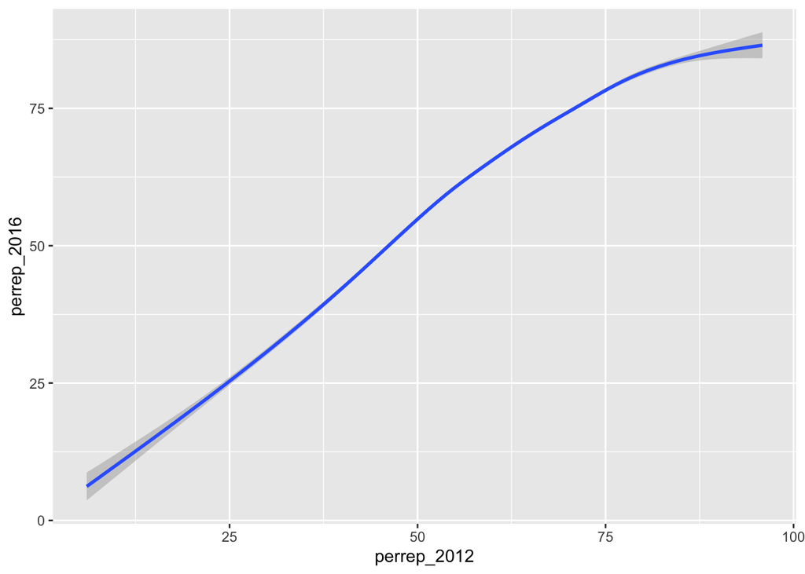

```r
ggplot(elect, aes(y=perrep_2016, x=perrep_2012)) +
        geom_smooth()
```

3. Notice that there are gray bands surrounding the blue model smooth line. What do these gray bars illustrate/capture and why are they widest at the “ends” of the model?

I believe that the grey bands represent the strength of the fit line at that point, so the parts with little to know grey band have enough data for the fit line to give a very good estimate, but towards the ends the grey fans out showing that there is not much data and theyy are not in the same so the line is likely a poor representation

4. By default, `geom_smooth` adds a smooth, localized model line. To examine the “best” *linear model*, we can specify `method="lm"`:

   ```r
   ggplot(elect, aes(y=perrep_2016, x=perrep_2012)) +
       geom_point() +
       geom_smooth(method="lm")
   ```

**Exercise 3.3 (Modify the Scatterplots)** As with univariate plots, we can change the aesthetics of scatterplots.

1. Add appropriate axis labels to your scatterplot. Label the y-axis “Trump 2016 support (%)” and label the x-axis “Romney 2012 support (%)”.
2. Change the color of the points.
3. Add some *transparency* to the points. NOTE: `alpha` can be between 0 (complete transparency) and 1 (no transparency).
4. Why is transparency useful in this particular graphic?

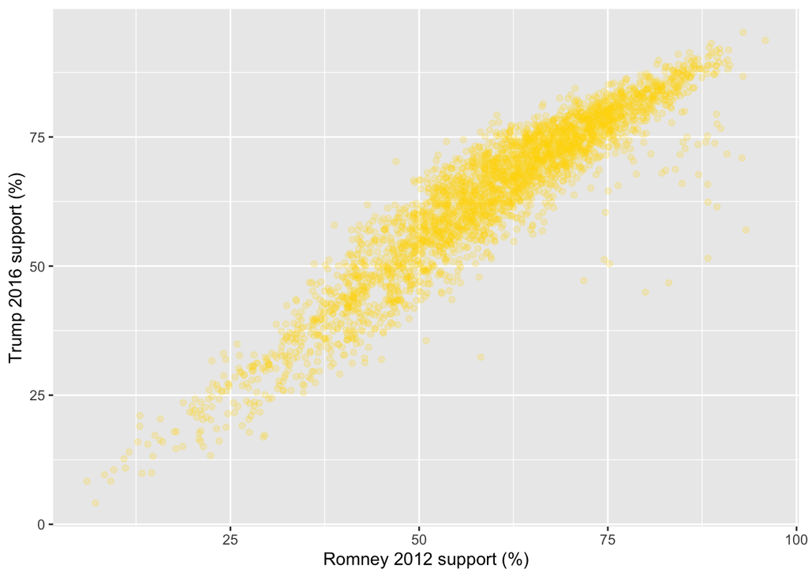

```r
ggplot(elect, aes(y=perrep_2016, x=perrep_2012)) +
    geom_point(color="Gold",alpha=0.2) +
    labs(x="Romney 2012 support (%)",y="Trump 2016 support (%)")
```

The transparency is good because it makes it a lot easier to tell where the extremely heavy data points are and where there is a lot of overlap

**Solution**

```r
ggplot(elect, aes(y=perrep_2016, x=perrep_2012)) +
    geom_point(color="brown",alpha=0.1) +
    labs(x="Romney 2012 support (%)",y="Trump 2016 support (%)")
```

**Exercise 3.4 (More Scatterplots)** 2012 results aren’t the only possible predictor of 2016 results. Consider two more possibilities.

1. Construct a scatterplot of `perrep_2016` and `median_rent`. Summarize the relationship between these two variables.

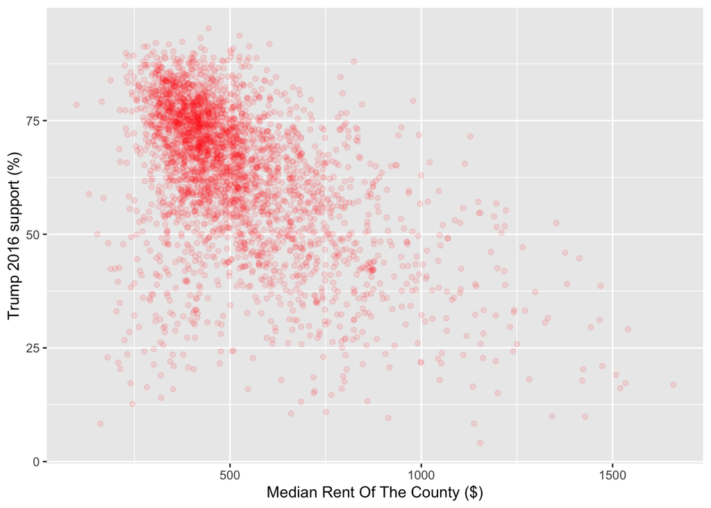

```r
ggplot(elect, aes(y=perrep_2016, x=median_rent)) +
    geom_point(color="Red",alpha=0.1) +
    labs(x="Median Rent Of The County ($)",y="Trump 2016 support (%)")
```

In this scatterplot we notice a weak, negative correlation between median rent of the county anf the percentasge of votes for Trump from that county. There are also more noticeable outliers towars low rent counties that did not vote for Trump

2. Construct a scatterplot of `perrep_2016` and `percent_white`. Summarize the relationship between these two variables.

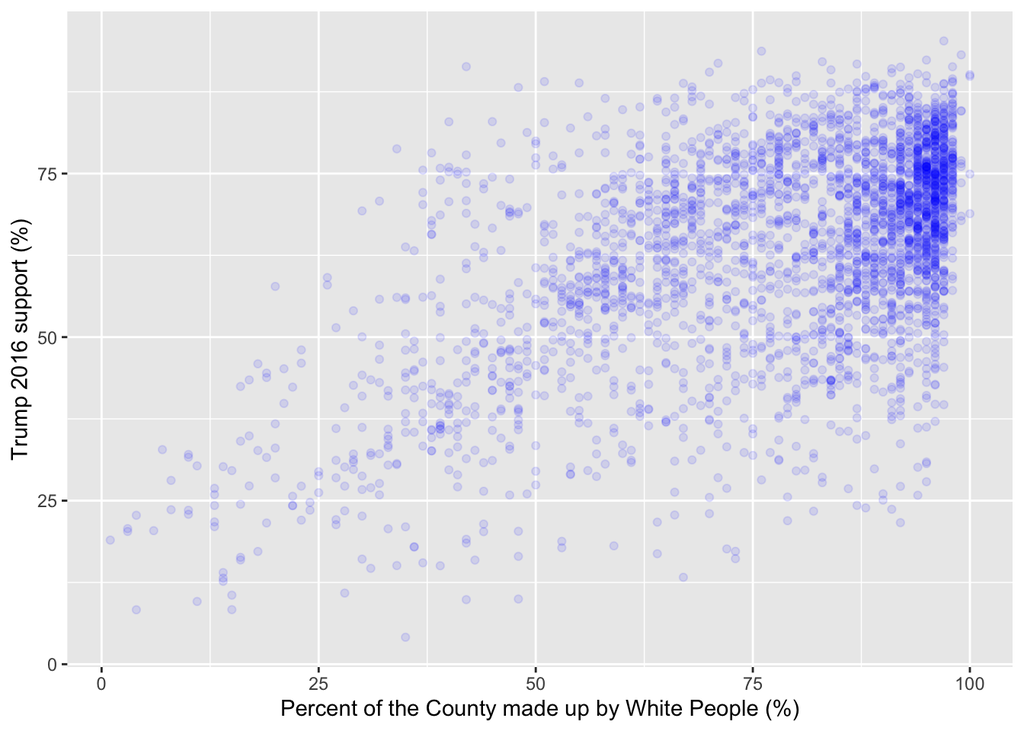

```r
ggplot(elect, aes(y=perrep_2016, x=percent_white)) +
    geom_point(color="Blue",alpha=0.1) +
    labs(x="Percent of the County made up by White People (%)",y="Trump 2016 support (%)")
```

This scatterplot shows a weak, positive relationship between the percentage of votes for Trump and the percentage of that county that is made up by white people without many outliers because the relationship is pretty weak.

3. Among `perrep_2012`, `median_rent` and `percent_white`, which is the best predictor of `perrep_2016`? Why?

# 4 Visualizing quantitative vs. categorical relationships

Consider a univariate histogram and density plot of `perrep_2016`:

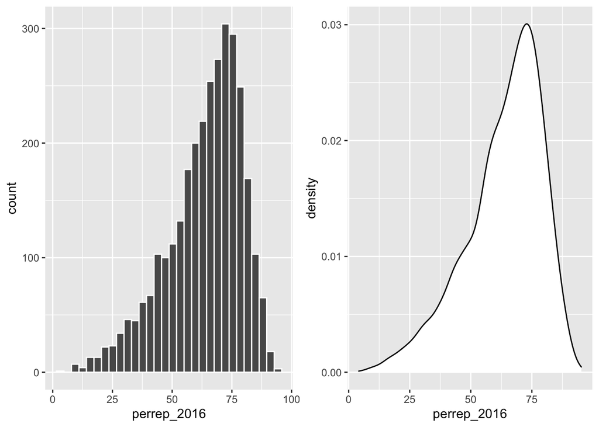

To visualize the relationship between Trump’s 2016 support (`perrep_2016`) and the `StateColor` (categorical) we need to incorporate a grouping mechanism. Work through the several options below.

**Exercise 4.1 (Side-by-Side Density Plots)** We can show density plots for each state color next to each other:

1. Construct a density plot for each group.

   ```r
   ggplot(elect, aes(x=perrep_2016, fill=StateColor)) +
       geom_density()
   ```

2. Notice that `ggplot` randomly assigns colors to group based on alphabetical order. In this example, the random color doesn’t match the group itself (red/purple/blue)! We can fix this:

   ```r
   ggplot(elect, aes(x=perrep_2016, fill=StateColor)) +
       geom_density() +
       scale_fill_manual(values=c("blue","purple","red"))
   ```

3. The overlap between the groups makes it difficult to explore the features of each. One option is to add *transparency* to the density plots:

   ```r
   ggplot(elect, aes(x=perrep_2016, fill=StateColor)) +
       geom_density(alpha=0.5) +
       scale_fill_manual(values=c("blue","purple","red"))
   ```

4. Yet another option is to separate the density plots into separate “facets” defined by group:

   ```r
   ggplot(elect, aes(x=perrep_2016, fill=StateColor)) +
       geom_density(alpha=0.5) +
       scale_fill_manual(values=c("blue","purple","red")) +
       facet_wrap( ~ StateColor)
   ```

**Exercise 4.2 (Side-by-Side Histograms)** Let’s try a similar strategy using histograms to illustrate the relationship between `perrep_2016` and `StateColor`.

1. Start with the default histogram:

   ```r
   ggplot(elect, aes(x=perrep_2016, fill=StateColor)) +
       geom_histogram(color="white")
   ```

2. That’s not very helpful! Separate the histograms into separate facets for each `StateColor` group.

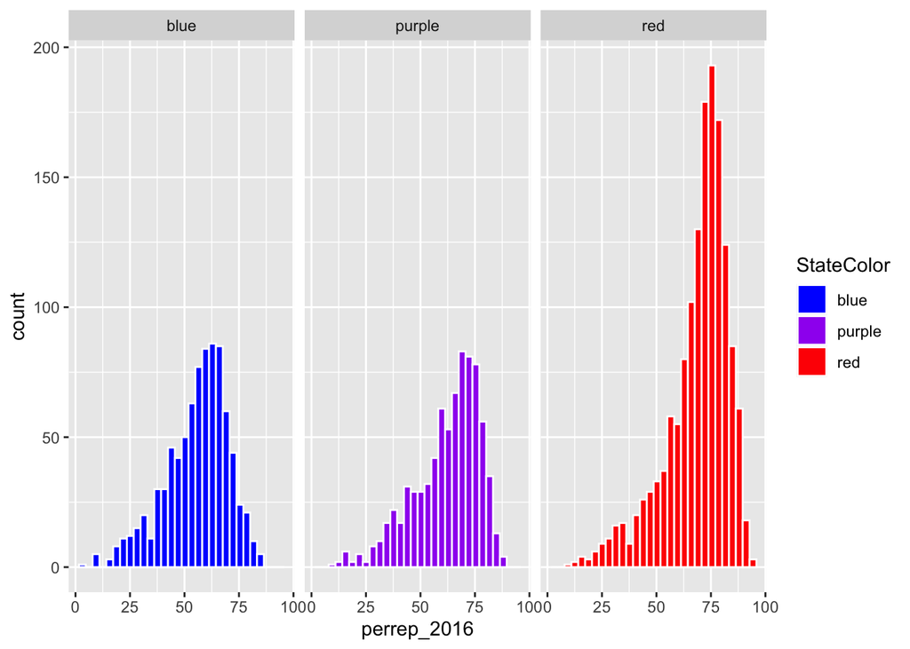

```r
ggplot(elect, aes(x=perrep_2016, fill=StateColor)) +
        geom_histogram(color="white") +
        scale_fill_manual(values=c("blue","purple","red")) +
        facet_wrap( ~ StateColor)
```

**Exercise 4.3 (More Options!)** Density plots and histograms aren’t the only type of viz we might use…

1. Construct side-by-side violins and side-by-side boxplots (see description below).

   ```r
   #violins instead
   ggplot(elect, aes(y=perrep_2016, x=StateColor)) +
       geom_violin()

   #boxes instead
   ggplot(elect, aes(y=perrep_2016, x=StateColor)) +
       geom_boxplot()
   ```

   Box plots are constructed from five numbers - the minimum, 25th percentile, median, 75th percentile, and maximum value of a quantitative variable:

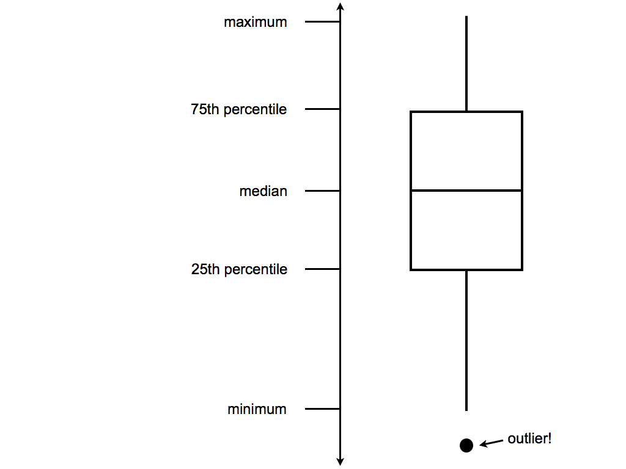

2. In the future, we’ll typically use *density plots* instead of histograms, violins, and boxes. Explain at least one pro and one con of the density plot.

The density plots are nice because it can give a great amount of specificity of the slopes of categorical variables and their values without having to use a histogram with extremely small bandwidths that are hard to read. A con though is that it may be telling a little bit more than is factually true if bandwidths are too small, for example in this case it could be giving count values for percentage of votes for republicans that are just nonexistent in America.

**Exercise 4.4** Let’s not forget the most important purpose of these visualizations! Summarize the relationship between Trump’s 2016 county-level support among red/purple/blue states.

# 5 Visualizing categorical vs categorical relationships

Finally, suppose that instead of Trump’s percentage support, we simply want to explore his county-level wins/losses:

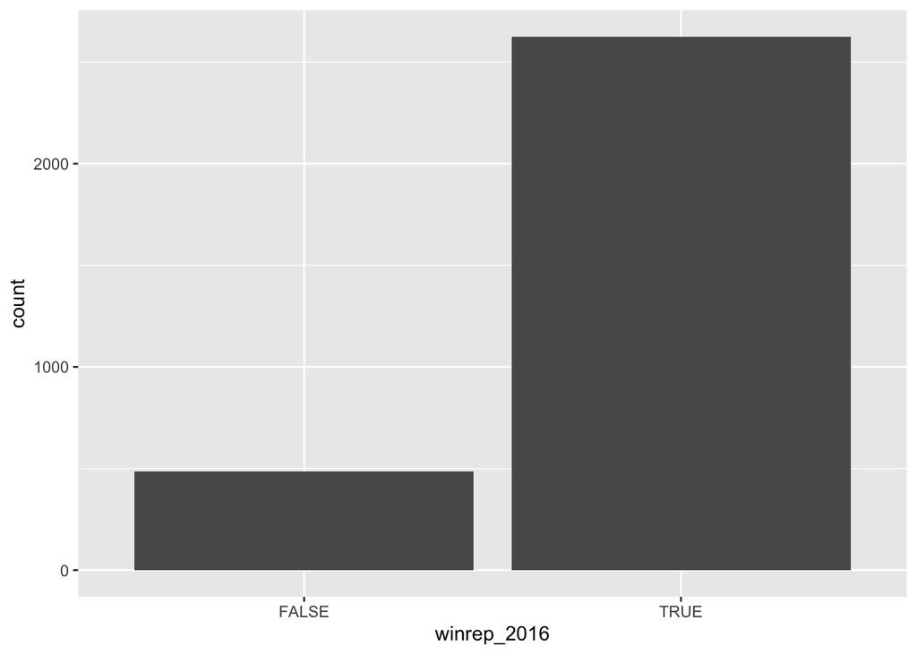

Specifically, let’s explore the relationship between `winrep_2016` and `StateColor`, another categorical variable.

**Exercise 5.1 (Side-by-side bar plots)** We saw above that we can incorporate a new categorical variable into a visualization by using grouping features such as color or facets. Let’s add information about `StateColor` to our bar plot of `winrep_2016`.

1. Construct the following 4 bar plot visualizations.

   ```r
   #a stacked bar plot
   ggplot(elect, aes(x=StateColor, fill=winrep_2016)) +
       geom_bar()

   #a side-by-side bar plot
   ggplot(elect, aes(x=StateColor, fill=winrep_2016)) +
       geom_bar(position="dodge")

   #a proportional bar plot
   ggplot(elect, aes(x=StateColor, fill=winrep_2016)) +
       geom_bar(position="fill")

   #faceted bar plot
   ggplot(elect, aes(x=StateColor, fill=winrep_2016)) +
       geom_bar() +
       facet_wrap( ~ winrep_2016)
   ```

2. Name one pro and one con of using the “proportional bar plot” instead of one of the other three options.  
   The pro is that it is easier to compare the full story of the graphs which is telling the proportion of counties won in republican votes in each type of state, blue, purple, and red. The con is that it is leaving out a specific count of each states counties.
3. What’s your favorite bar plot from part (a)? Why?

My favorite plot is the stacked bar plot because I believe it still shows the proportions in each of the types of states well enough of counties voting republican or not, but does so in a way where they are not too far separated and each type of state can be easily compared.

# 6 Practice

## 6.1 Hot Dogs

In the annual Nathan’s hot dog eating contest, people compete to eat as many hot dogs as possible in ten minutes. Data on past competitions were compiled by Nathan Yau for “Visualize This: The FlowingData Guide to Design, Visualization, and Statistics”:

```r
hotdogs <- read_csv("http://datasets.flowingdata.com/hot-dog-contest-winners.csv")
```

**Exercise 6.1**

1. Construct a visualization of the winning number of hot dogs by year. THINK: Which is the response variable?
2. Temporal trends are often visualized using a line plot. Add a `geom_line()` layer to your plot from part (a).
3. Summarize your observations about the temporal trends in the hot dog contest.

```r
head(hotdogs)
```

```
## # A tibble: 6 × 5
##    Year Winner                       `Dogs eaten` Country       `New record`
##   <dbl> <chr>                               <dbl> <chr>                <dbl>
## 1  1980 Paul Siederman & Joe Baldini          9.1 United States            0
## 2  1981 Thomas DeBerry                       11   United States            0
## 3  1982 Steven Abrams                        11   United States            0
## 4  1983 Luis Llamas                          19.5 Mexico                   0
## 5  1984 Birgit Felden                         9.5 Germany                  0
## 6  1985 Oscar Rodriguez                      11.8 United States            0
```

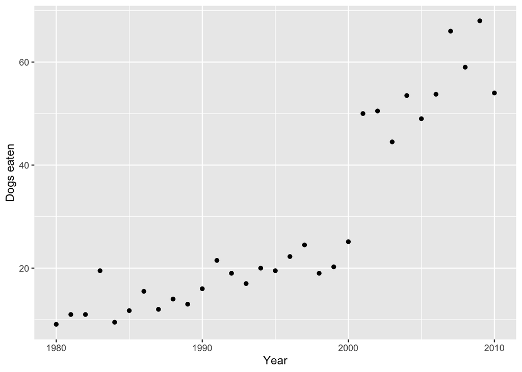

```r
ggplot(hotdogs, aes(y=`Dogs eaten`, x=Year)) +
        geom_point()
```

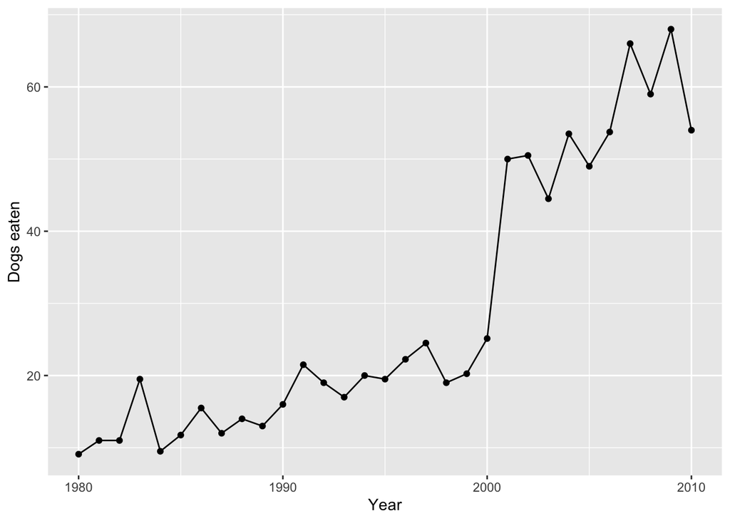

```r
ggplot(hotdogs, aes(y=`Dogs eaten`, x=Year)) +
        geom_point()+
        geom_line()
```

**Exercise 6.2** All but two of the past winners are from the U.S. or Japan:

```r
table(hotdogs$Country)
```

```
##
##       Germany         Japan        Mexico United States
##             1             9             1            20
```

Use the following code to *filter* out just the winners from U.S. and Japan and name this `hotdogsSub`. (Don’t worry about the code itself - we’ll discuss similar syntax later in the semester!)

```r
library(dplyr)
hotdogsSub <- hotdogs %>%
    filter(Country %in% c("Japan","United States"))
```

1. Using a density plot approach *without* facets, construct a visualization of how the number of hot dogs eaten varies by country.

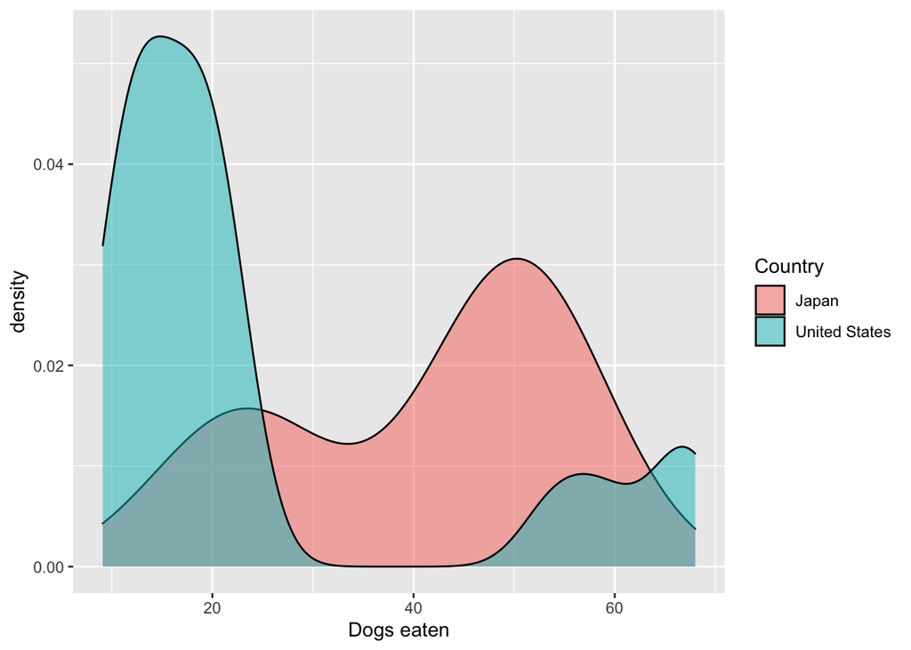

```r
ggplot(hotdogsSub, aes(x=`Dogs eaten`, fill=Country)) +
        geom_density(alpha=0.5)
```

2. Repeat part a using a density plot approach *with* facets.

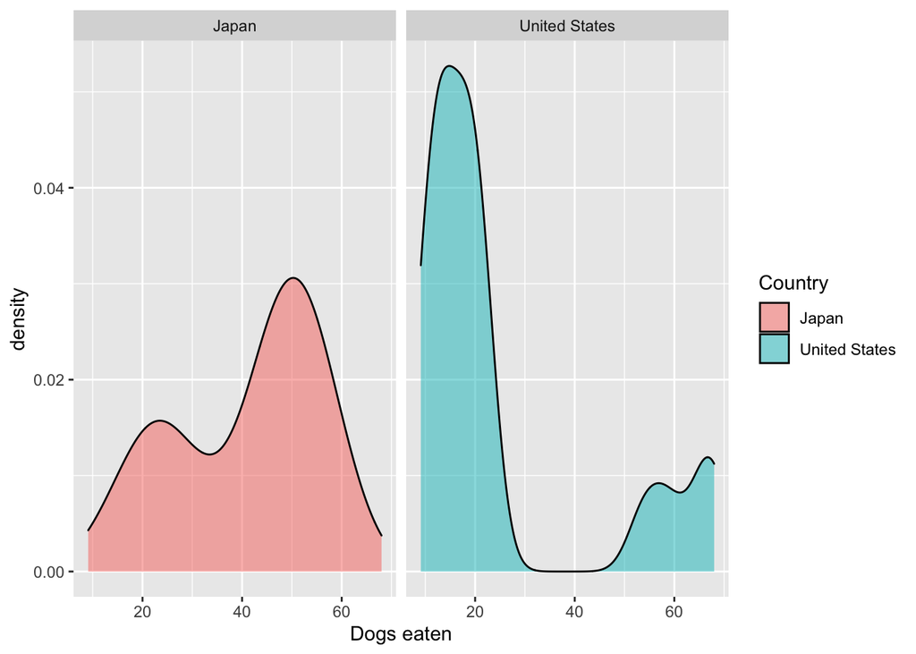

```r
ggplot(hotdogsSub, aes(x=`Dogs eaten`, fill=Country)) +
        geom_density(alpha=0.5) +
        facet_wrap( ~ Country)
```

3. Repeat part a using *something other than* a density plot approach. (There are a few options!)

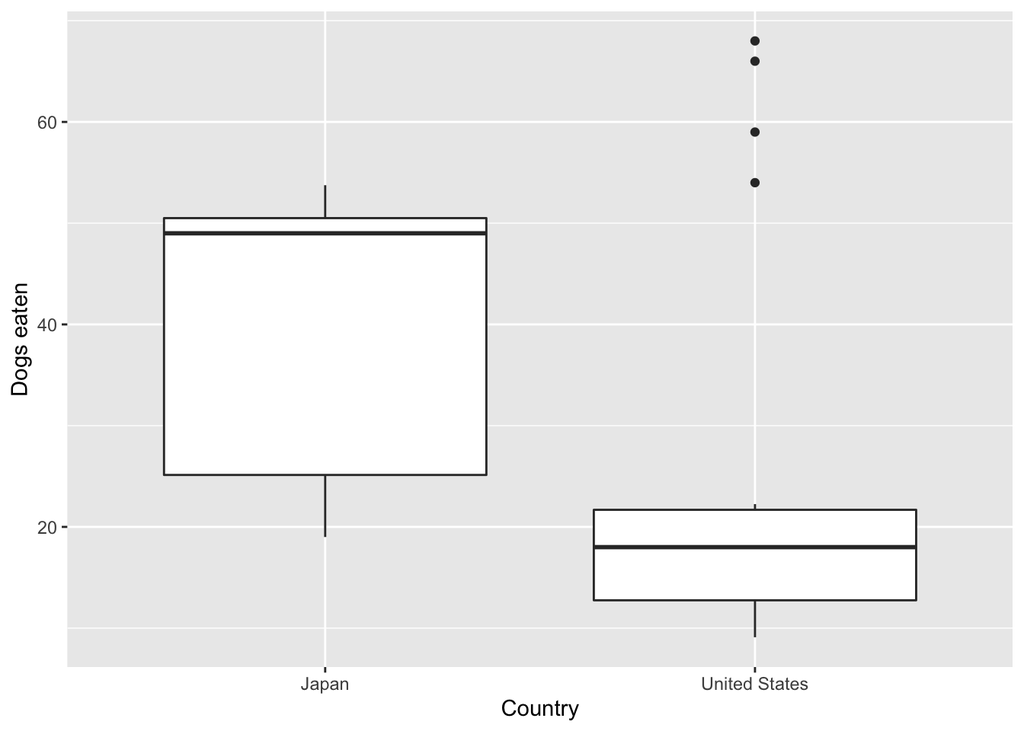

```r
ggplot(hotdogsSub, aes(y=`Dogs eaten`, x=Country)) +
        geom_boxplot()
```

4. Summarize your observations about the number of hot dogs eaten by country.

America seems to have much more of the extreme case winners as they have very few winners eating 30-50 hot dogs but more of the 60+ hot dog eaters and 10-20 hot dog eating winners. Japan on the other hand was much ore spread out with their winners but they did show peaks with a lot of winners eating around 25 hot dogs and their highest density eating around 50 hot dogs when they won.

## 6.2 The Bechdel Test

Recall the “Bechdel test” data from the previous activity. As a reminder, the “Bechdel test” tests whether movies meet the following criteria:

- there are $\ge$ 2 female characters
- the female characters talk to each other
- at least 1 time, they talk about something other than a male character

In the fivethirtyeight.com article [“The Dollar-And-Cents Case Against Hollywood’s Exclusion of Women”](http://fivethirtyeight.com/features/the-dollar-and-cents-case-against-hollywoods-exclusion-of-women/), the authors analyze which Hollywood movies do/don’t pass the test. Their data are available in the `fivethirtyeight` package:

```r
library(fivethirtyeight)
data(bechdel)
```

In investigating budgets and profits, the authors “focus on films released from 1990 to 2013, since the data has significantly more depth since then.” Use the following code to filter out just the movies in these years and name the resulting data set `Beyond1990` (don’t worry about the syntax):

```r
library(dplyr)
Beyond1990 <- bechdel %>%
    filter(year >= 1990)
```

**Exercise 6.3**

1. Construct a visualization that addresses the following research question: Do bigger budgets (`budget_2013`) pay off with greater box office returns (`domgross_2013`)? In constructing this visualization, add a smooth to highlight trends and pay attention to which of these variables is the response.
2. Using your visualization as supporting evidence, answer the research question.
3. Part of the fivethirtyeight article focuses on how budgets (`budget_2013`) differ among movies with different degrees of female character development (`clean_test`). Construct a visualization that highlights the relationship between these two variables. There are many options - some are better than others!
4. Using your visualization as supporting evidence, address fivethirtyeight’s concerns.

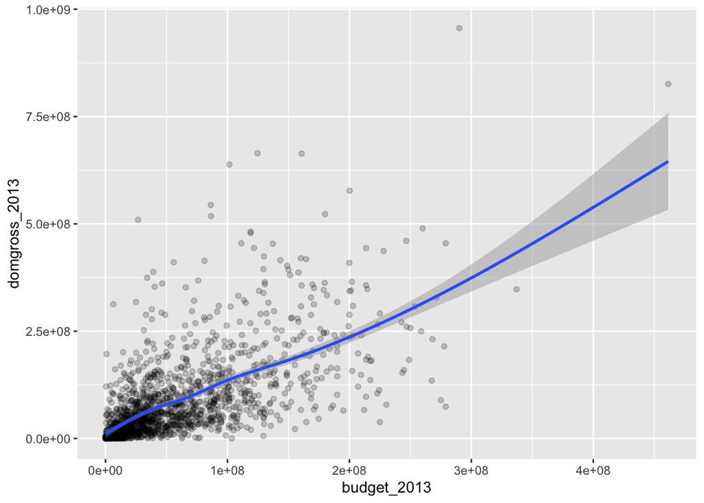

```r
ggplot(Beyond1990, aes(y=domgross_2013, x=budget_2013)) +
        geom_point(alpha=0.2) +
        geom_smooth()
```

This data shows that as the budget of a movie increases, profits also tend to increase

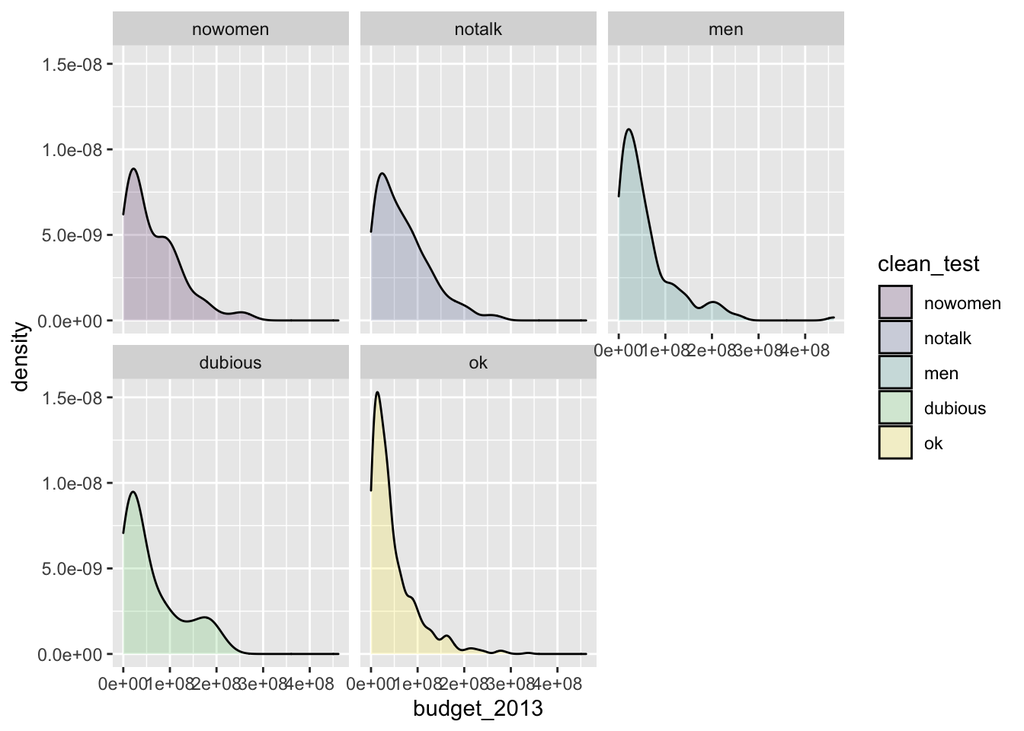

```r
ggplot(Beyond1990, aes(x=budget_2013, fill=clean_test)) +
        geom_density(alpha=0.2) +
  facet_wrap(~ clean_test)
```

This data shows that as budget increases, less movies actually pass the bechdel test.

**Exercise 6.4** NOTE: The following exercise is inspired by a similar exercise proposed by Albert Kim, one of the `fivethirtyeight` package authors.  
Return to the fivethirtyeight.com article and examine the plot titled “The Bechdel Test Over Time”.

1. Summarize the trends captured by this plot. (How has the representation of women in movies evolved over time?)

As time has passed, there has been a growth of women representation in movies as the percentage of movies that pass the bechdel test has increased. Particularly in the 90’s we notice a pretty steep increase in the proportion of movies that pass the test. After that though, in the 2000’s we actually see a steady, slow decrease in the proportion of movies passing the test.

2. Recreate this plot! To do so, you’ll need to create a new data set named `newbechdel` in which the order of the Bechdel categories (`clean_test`) and the year categories (`yearCat`) match those used by fivethirtyeight. Don’t worry about the syntax:

   ```r
   library(dplyr)
   newbechdel <- bechdel %>%
       mutate(clean_test=factor(bechdel$clean_test, c("nowomen","notalk","men","dubious","ok"))) %>%
       mutate(yearCat=cut(year, breaks=seq(1969,2014,by=5)))
   ```

   Further, you’ll need to add the following layer in order to get a color scheme that’s close to that in the article:

   ```r
   scale_fill_manual(values = c("red","salmon","pink","steelblue1","steelblue4"))
   ```

   NOTE that your plot won’t look *exactly* like the authors’, but should be close to this:

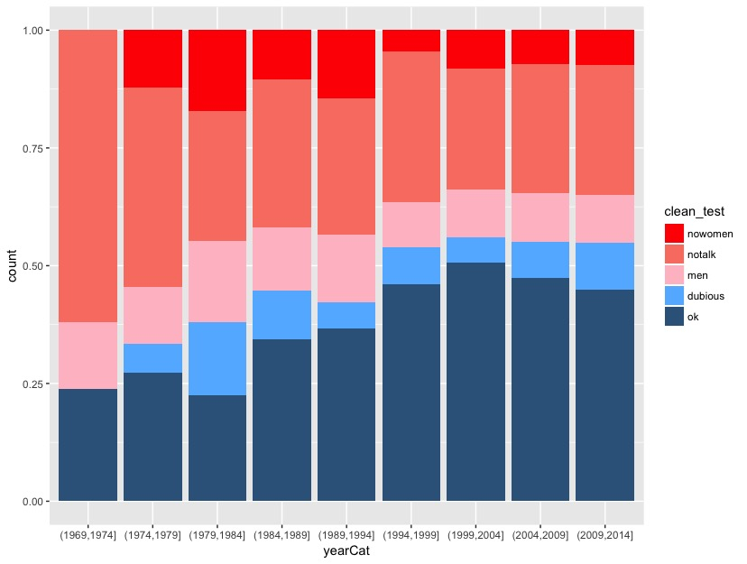

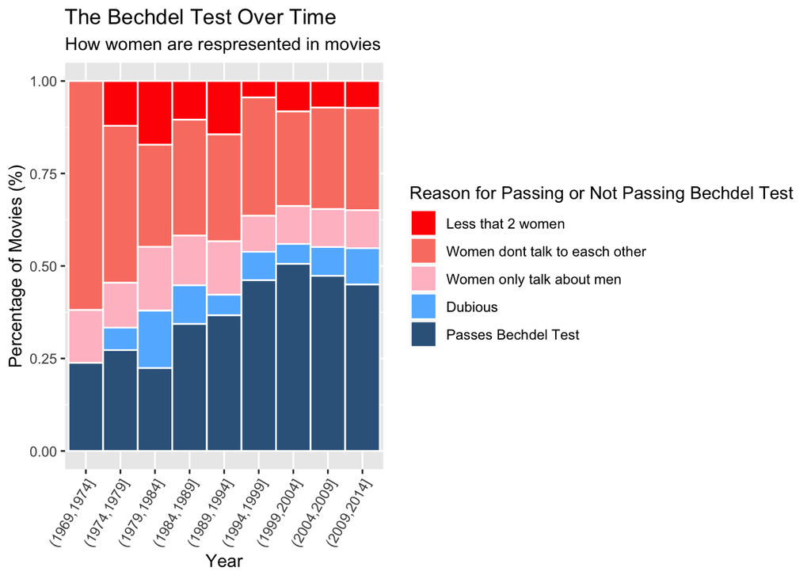

```r
  ggplot(newbechdel, aes(x=yearCat, fill=clean_test)) +
        geom_bar(position="fill", width = 1, color = "White") +
  scale_fill_manual(values = c("red","salmon","pink","steelblue1","steelblue4"), labels = c("Less that 2 women", "Women dont talk to easch other", "Women only talk about men", "Dubious", "Passes Bechdel Test"))+
  theme(axis.text.x = element_text(angle = 60, hjust = 1))+
  labs(title = "The Bechdel Test Over Time", subtitle = "How women are respresented in movies", x="Year",y="Percentage of Movies (%)", fill = "Reason for Passing or Not Passing Bechdel Test")
```